# The Underdogs of the NBA: An Analysis of Facilitators

## By Jim Huang and Zac Thamer

[figure not shown]

[[NBA Players: James Harden (Left) and Chris Paul (Right)]](https://i.insider.com/5d0952ae638af211863e6eb6?width=1136&format=jpeg)

### *Introduction:*

In order to win an NBA championship, teams must have a variety of players, each with their own unique skill set that is able to fill in the gaps in their team's talent. Some players are known to be facilitators who are best at getting the most out of their teammates and "controlling" the pace of the game, while other players may be known to be scorers who are able to create their own shot and get a basket at any time. Naturally, facilitators pass the ball more to their teammates in order to make the best decision and boost the confidence of their teammates, while scorers may take more shots and pass less. Thus, in terms of the stat sheet, facilitators may have more assists, while scorers may specialize in shots taken and points per game. **In this analysis, we will attempt to predict a player's assists per game using certain characteristics that define scorers (we will conduct this analysis for both the regular season dataset and the postseason). More specifically, we will look for a linear relationship between assists per game and these characteristics.** We are going to conduct this analysis based on the players in the top teams (the teams that made it to the NBA playoffs) as the players in these teams are, on average, discussed about more in terms of trades and contracts. The thought process behind this study is that players who score and shoot more have less assists because they spend a lot of their possessions on themselves. One prime example of this is the player, James Harden, especially during his time on the Houston Rockets. James Harden was known to be a ball hog and rarely pass the ball due to his extreme talent and scoring abilities. The information from this analysis could prove to be very useful to general managers and coaches who are looking to add facilitators or scorers to their team that are within their budget.

### *Data Collection/Curation*

If we want to conduct an analysis, we need some data; collecting data is the first step in the data science pipeline.

For our specific case, we simply downloaded the data and made necessary adjustments so that we could work with it. The data can be downloaded [here](https://www.nbastuffer.com/2021-2022-nba-player-stats/). The original format of the data came as a .xlsx file. So, in order to work with the file as a csv, we opened the .xlsx file using Excel. Then, we deleted unnecessary text in the .xlsx so the column names would be correct because there was an unnecessary cell with the text "NBA Stats 2021/22:All Player Statistics in one Page" that was causing python to read this text in as the column names instead of the row below. Then, we downloaded the data as a .csv and proceeded to use pandas to convert the csv into a dataframe.

Another way to gather data is to scrape it from a website. Essentially, we will create a table out of the HTML from a website. Web scraping is a very powerful tool that is very versatile and easy to learn. Check out this [comprehensive guide on web scraping](https://www.cloudflare.com/learning/bots/what-is-data-scraping/) to learn more.

```python
# Importing dependencies
import pandas as pd
import numpy as np
import warnings
warnings.filterwarnings("ignore")
import matplotlib.pyplot as plt
import seaborn as sns
import statsmodels.formula.api as smf
import matplotlib.pyplot as plt
from statsmodels.formula.api import ols
from sklearn.linear_model import LinearRegression
from scipy.stats import pearsonr
```

```python
# Reading in Data
regularSeason = pd.read_csv("NBARegularSeasonStats.csv")
playoffSeason = pd.read_csv("NBAPlayoffStats.csv")

# Printing out first few rows of the dataset
regularSeason.head()
```

|  | RANK | FULL NAME | TEAM | POS | AGE | GP | MPG | MIN%Minutes PercentagePercentage of team minutes used by a player while he was on the floor | USG%Usage RateUsage rate, a.k.a., usage percentage is an estimate of the percentage of team plays used by a player while he was on the floor | TO%Turnover RateA metric that estimates the number of turnovers a player commits per 100 possessions | ... | RPGReboundsRebounds per game. | TRB%Total Rebound PercentageTotal rebound percentage is estimated percentage of available rebounds grabbed by the player while the player is on the court. | APGAssistsAssists per game. | AST%Assist PercentageAssist percentage is an estimated percentage of teammate field goals a player assisted while the player is on the court | SPGStealsSteals per game. | BPGBlocksBlocks per game. | TOPGTurnoversTurnovers per game. | VIVersatility IndexVersatility index is a metric that measures a player’s ability to produce in points, assists, and rebounds. The average player will score around a five on the index, while top playe… | ORTGOffensive RatingIndividual offensive rating is the number of points produced by a player per 100 total individual possessions. | DRTGDefensive RatingIndividual defensive rating estimates how many points the player allowed per 100 possessions he individually faced while staying on the court. |
| --- | --- | --- | --- | --- | --- | --- | --- | --- | --- | --- | --- | --- | --- | --- | --- | --- | --- | --- | --- | --- | --- |
| 0 | NaN | Precious Achiuwa | Tor | F | 22.56 | 73 | 23.6 | 49.2 | 18.5 | 11.3 | ... | 6.5 | 14.9 | 1.1 | 6.9 | 0.51 | 0.56 | 1.15 | 6.8 | 105.4 | 104.0 |
| 1 | NaN | Steven Adams | Mem | C | 28.73 | 76 | 26.3 | 54.8 | 12.0 | 19.6 | ... | 10.0 | 19.9 | 3.4 | 16.1 | 0.87 | 0.79 | 1.51 | 9.4 | 124.7 | 103.9 |
| 2 | NaN | Bam Adebayo | Mia | C-F | 24.73 | 56 | 32.6 | 67.9 | 25.0 | 14.4 | ... | 10.1 | 17.5 | 3.4 | 17.5 | 1.43 | 0.79 | 2.64 | 10.7 | 117.2 | 98.2 |
| 3 | NaN | Santi Aldama | Mem | F-C | 21.25 | 32 | 11.2 | 23.4 | 18.5 | 9.9 | ... | 2.7 | 12.6 | 0.7 | 7.7 | 0.19 | 0.31 | 0.50 | 7.1 | 101.1 | 103.9 |
| 4 | NaN | LaMarcus Aldridge | Bro | C-F | 36.73 | 47 | 22.3 | 46.5 | 22.4 | 8.0 | ... | 5.5 | 13.4 | 0.9 | 6.3 | 0.30 | 1.00 | 0.94 | 7.2 | 119.6 | 108.8 |

5 rows × 29 columns

```python
playoffSeason.head()
```

|  | RANK | FULL NAME | TEAM | POS | AGE | GP | MPG | MIN%Minutes PercentagePercentage of team minutes used by a player while he was on the floor | USG%Usage RateUsage rate, a.k.a., usage percentage is an estimate of the percentage of team plays used by a player while he was on the floor | TO%Turnover RateA metric that estimates the number of turnovers a player commits per 100 possessions | ... | RPGReboundsRebounds per game. | TRB%Total Rebound PercentageTotal rebound percentage is estimated percentage of available rebounds grabbed by the player while the player is on the court. | APGAssistsAssists per game. | AST%Assist PercentageAssist percentage is an estimated percentage of teammate field goals a player assisted while the player is on the court | SPGStealsSteals per game. | BPGBlocksBlocks per game. | TOPGTurnoversTurnovers per game. | VIVersatility IndexVersatility index is a metric that measures a player’s ability to produce in points, assists, and rebounds. The average player will score around a five on the index, while top playe… | ORTGOffensive RatingIndividual offensive rating is the number of points produced by a player per 100 total individual possessions. | DRTGDefensive RatingIndividual defensive rating estimates how many points the player allowed per 100 possessions he individually faced while staying on the court. |
| --- | --- | --- | --- | --- | --- | --- | --- | --- | --- | --- | --- | --- | --- | --- | --- | --- | --- | --- | --- | --- | --- |
| 0 | NaN | Precious Achiuwa | Tor | F | 22.63 | 6 | 27.8 | 57.8 | 18.2 | 13.8 | ... | 4.8 | 10.7 | 1.0 | 5.7 | 0.17 | 0.83 | 1.50 | 5.3 | 103.3 | 107.9 |
| 1 | NaN | Steven Adams | Mem | C | 28.79 | 3 | 10.2 | 21.3 | 1.3 | 100.0 | ... | 1.7 | 8.8 | 1.3 | 15.9 | 0.00 | 0.00 | 0.33 | 0.0 | NaN | 92.3 |
| 2 | NaN | Bam Adebayo | Mia | C-F | 24.80 | 7 | 32.0 | 66.6 | 19.8 | 19.0 | ... | 8.7 | 16.4 | 3.6 | 16.8 | 1.14 | 0.57 | 2.71 | 9.8 | 124.0 | 99.2 |
| 3 | NaN | Nickeil Alexander-Walker | Uta | G | 23.67 | 1 | 4.7 | 9.8 | 24.4 | 0.0 | ... | 1.0 | 12.4 | 1.0 | 70.1 | 1.00 | 0.00 | 0.00 | 14.6 | 214.3 | 100.3 |
| 4 | NaN | Grayson Allen | Mil | G | 26.57 | 7 | 25.4 | 52.9 | 14.6 | 6.8 | ... | 3.0 | 6.0 | 0.6 | 3.5 | 1.14 | 0.43 | 0.57 | 4.3 | 132.9 | 107.1 |

5 rows × 29 columns

Here, we cannot see all of the columns for both dataframes since there are too many, so we will print out the columns in each.

```python
# Printing out column names
regularSeason.columns
```

```
Index(['RANK', 'FULL NAME', 'TEAM', 'POS', 'AGE', 'GP', 'MPG',
       'MIN%Minutes PercentagePercentage of team minutes used by a player while he was on the floor',
       'USG%Usage RateUsage rate, a.k.a., usage percentage is an estimate of the percentage of team plays used by a player while he was on the floor',
       'TO%Turnover RateA metric that estimates the number of turnovers a player commits per 100 possessions',
       'FTA', 'FT%', '2PA', '2P%', '3PA', '3P%',
       'eFG%Effective Shooting PercentageWith eFG%, three-point shots made are worth 50% more than two-point shots made. eFG% Formula=(FGM+ (0.5 x 3PM))/FGA',
       'TS%True Shooting PercentageTrue shooting percentage is a measure of shooting efficiency that takes into account field goals, 3-point field goals, and free throws.',
       'PPGPointsPoints per game.', 'RPGReboundsRebounds per game.',
       'TRB%Total Rebound PercentageTotal rebound percentage is estimated percentage of available rebounds grabbed by the player while the player is on the court.',
       'APGAssistsAssists per game.',
       'AST%Assist PercentageAssist percentage is an estimated percentage of teammate field goals a player assisted while the player is on the court',
       'SPGStealsSteals per game.', 'BPGBlocksBlocks per game.',
       'TOPGTurnoversTurnovers per game.',
       'VIVersatility IndexVersatility index is a metric that measures a player’s ability to produce in points, assists, and rebounds. The average player will score around a five on the index, while top players score above 10',
       'ORTGOffensive RatingIndividual offensive rating is the number of points produced by a player per 100 total individual possessions.',
       'DRTGDefensive RatingIndividual defensive rating estimates how many points the player allowed per 100 possessions he individually faced while staying on the court.'],
      dtype='object')
```

```python
playoffSeason.columns
```

```
Index(['RANK', 'FULL NAME', 'TEAM', 'POS', 'AGE', 'GP', 'MPG',
       'MIN%Minutes PercentagePercentage of team minutes used by a player while he was on the floor',
       'USG%Usage RateUsage rate, a.k.a., usage percentage is an estimate of the percentage of team plays used by a player while he was on the floor',
       'TO%Turnover RateA metric that estimates the number of turnovers a player commits per 100 possessions',
       'FTA', 'FT%', '2PA', '2P%', '3PA', '3P%',
       'eFG%Effective Shooting PercentageWith eFG%, three-point shots made are worth 50% more than two-point shots made. eFG% Formula=(FGM+ (0.5 x 3PM))/FGA',
       'TS%True Shooting PercentageTrue shooting percentage is a measure of shooting efficiency that takes into account field goals, 3-point field goals, and free throws.',
       'PPGPointsPoints per game.', 'RPGReboundsRebounds per game.',
       'TRB%Total Rebound PercentageTotal rebound percentage is estimated percentage of available rebounds grabbed by the player while the player is on the court.',
       'APGAssistsAssists per game.',
       'AST%Assist PercentageAssist percentage is an estimated percentage of teammate field goals a player assisted while the player is on the court',
       'SPGStealsSteals per game.', 'BPGBlocksBlocks per game.',
       'TOPGTurnoversTurnovers per game.',
       'VIVersatility IndexVersatility index is a metric that measures a player’s ability to produce in points, assists, and rebounds. The average player will score around a five on the index, while top players score above 10',
       'ORTGOffensive RatingIndividual offensive rating is the number of points produced by a player per 100 total individual possessions.',
       'DRTGDefensive RatingIndividual defensive rating estimates how many points the player allowed per 100 possessions he individually faced while staying on the court.'],
      dtype='object')
```

### *Data management/representation*

Cleaning the data is a crucial aspect of the data science pipeline. If performed correctly, this step will allow us to easily work with the data that we have and also allow other readers/users to interpret our dataset. For a general guide on good data cleaning practices, check out this [link](https://www.tableau.com/learn/articles/what-is-data-cleaning). Some of the common techniques used in the data management process are extracting only the necessary columns, renaming columns, and accounting for missing values.

We will be using the full name (FULL NAME), position (POS), two point percentage (2Perc), 2 point attempts (2PA), 3 point percentage (3Perc), 3 point attempts (3PA), free throw percentage (FT%), free throw attempts (FTA) columns, assists per game (APG), and points per game (PPG) columns. Thus, it is best to clean up the dataframes such that we don't have unnecessary clutter so we can better visualize that the dataframe that we are working with. In addition, we will rename the columns as some of the columns are unnecessarily long and unreadable.

```python
# Retrieving specific columns from dataset
regularSeasonFilteredColumns = regularSeason[["FULL NAME", "POS", "2P%", "2PA", "3P%", "3PA", "FT%", "FTA", "APGAssistsAssists per game.", "PPGPointsPoints per game."]]

# Renaming columns in our dataset
regularSeasonFilteredColumns.rename(columns = {"2P%": "2Perc", "3P%": "3Perc", "APGAssistsAssists per game.":"APG", "PPGPointsPoints per game.": "PPG"}, inplace = True)

regularSeasonFilteredColumns.head()
```

|  | FULL NAME | POS | 2Perc | 2PA | 3Perc | 3PA | FT% | FTA | APG | PPG |
| --- | --- | --- | --- | --- | --- | --- | --- | --- | --- | --- |
| 0 | Precious Achiuwa | F | 0.468 | 447 | 0.359 | 156 | 0.595 | 131 | 1.1 | 9.1 |
| 1 | Steven Adams | C | 0.548 | 383 | 0.000 | 1 | 0.543 | 199 | 3.4 | 6.9 |
| 2 | Bam Adebayo | C-F | 0.562 | 723 | 0.000 | 6 | 0.753 | 340 | 3.4 | 19.1 |
| 3 | Santi Aldama | F-C | 0.560 | 84 | 0.125 | 48 | 0.625 | 32 | 0.7 | 4.1 |
| 4 | LaMarcus Aldridge | C-F | 0.578 | 412 | 0.304 | 46 | 0.873 | 102 | 0.9 | 12.9 |

```python
# Repeating same thing with playoffs dataset
playoffSeasonFilteredColumns = playoffSeason[["FULL NAME", "POS", "2P%", "2PA", "3P%", "3PA", "FT%", "FTA", "APGAssistsAssists per game.", "PPGPointsPoints per game."]]
playoffSeasonFilteredColumns.rename(columns = {"2P%": "2Perc", "3P%": "3Perc", "APGAssistsAssists per game.":"APG", "PPGPointsPoints per game.": "PPG"}, inplace = True)

playoffSeasonFilteredColumns.head()
```

|  | FULL NAME | POS | 2Perc | 2PA | 3Perc | 3PA | FT% | FTA | APG | PPG |
| --- | --- | --- | --- | --- | --- | --- | --- | --- | --- | --- |
| 0 | Precious Achiuwa | F | 0.556 | 36 | 0.313 | 16 | 0.600 | 10 | 1.0 | 10.2 |
| 1 | Steven Adams | C | 0.000 | 0 | 0.000 | 0 | 0.000 | 0 | 1.3 | 0.0 |
| 2 | Bam Adebayo | C-F | 0.587 | 63 | 0.000 | 0 | 0.854 | 41 | 3.6 | 15.6 |
| 3 | Nickeil Alexander-Walker | G | 1.000 | 2 | 0.000 | 0 | 1.000 | 1 | 1.0 | 5.0 |
| 4 | Grayson Allen | G | 0.619 | 21 | 0.548 | 31 | 0.571 | 7 | 0.6 | 11.6 |

As mentioned previously, we **only want to conduct the analysis on players who made it to the playoffs**. Thus, we will filter out the regular season dataset to only include players that are in the playoff dataset.

```python
# Here, we will remove players that are not in the playoff dataset

# Get list of all players in playoffs
playersInPlayoffs = playoffSeasonFilteredColumns["FULL NAME"].tolist()
playersInPlayoffs

rowsToDelete = []

# Search to see if the current player is not in the playoffs so we can store the index to remove it later
for index, row in regularSeasonFilteredColumns.iterrows():
    if (not (row["FULL NAME"] in playersInPlayoffs)):
        rowsToDelete.append(index)

# Remove all rows based on indices from before
regularSeasonFilteredWithoutPlayers = regularSeasonFilteredColumns.drop(rowsToDelete, axis=0)
regularSeasonFilteredWithoutPlayers.head()
```

|  | FULL NAME | POS | 2Perc | 2PA | 3Perc | 3PA | FT% | FTA | APG | PPG |
| --- | --- | --- | --- | --- | --- | --- | --- | --- | --- | --- |
| 0 | Precious Achiuwa | F | 0.468 | 447 | 0.359 | 156 | 0.595 | 131 | 1.1 | 9.1 |
| 1 | Steven Adams | C | 0.548 | 383 | 0.000 | 1 | 0.543 | 199 | 3.4 | 6.9 |
| 2 | Bam Adebayo | C-F | 0.562 | 723 | 0.000 | 6 | 0.753 | 340 | 3.4 | 19.1 |
| 5 | Nickeil Alexander-Walker | G | 0.434 | 327 | 0.311 | 305 | 0.722 | 97 | 2.8 | 12.8 |
| 6 | Nickeil Alexander-Walker | G | 0.400 | 15 | 0.303 | 33 | 0.917 | 12 | 1.1 | 3.5 |

At this step, we realized that there were **duplicate players in the regular season dataframe if the player had been traded throughout the regular season.** So, we have to find a way to deal with this. An important aspect of data science is learning how to understand your data and justifying the way you handle data!

One option would be to simply remove all entries of the player from the dataframe if we do not wish to include their data in the dataframe. Although this would be easier to do, we would suffer from losing valuable data that may also make our analysis inaccurate.

Another option, which is likely to be more accurate for our analysis, is to average the players' statistics. For example, we have the number of attempts for each type of shot (2s, 3s, free throws) and the respective success percentages. Thus, we can calculate the total number of raw makes by multiplying the success percentage by the attempts. Now, we can do this for the player's entries on both teams. Now, we can sum the makes, sum the total number of shots, and divide the two values to get an accurate shooting percentage. Then, we can remove both the duplicate entries and add a new entry with the correct average percentages. In addition, for PPG and APG, we can simply take the average of the values for the duplicate players since the values are already averaged by game. *Note: No two players have played at the same time with the same name in the NBA (based on a quick google search), so we don't need to worry about accidentally averaging two unique players.*

```python
# List of player names
playerNames = regularSeasonFilteredWithoutPlayers["FULL NAME"].tolist()

# Store player names as a set so each name is unique
playerNamesSet = set(playerNames)
duplicatePlayers = []

# Iterate through the names of the players and store the names of the duplicate players
for x in playerNamesSet:
    # This way, we don't double count duplicates
    if playerNames.count(x) > 1:
        duplicatePlayers.append(x)

        while playerNames.count(x) >= 1:
            playerNames.remove(x)

cumulativeStats = []
duplicateIndices = []
# Iterate through duplicate players
for x in duplicatePlayers:
    total2Attempts = 0
    total3Attempts = 0
    totalFTAttempts = 0
    total2Made = 0
    total3Made = 0
    totalFTMade = 0
    final2Perc = 0
    final3Perc = 0
    finalFTPerc = 0
    ppgSum = 0
    apgSum = 0
    finalPPG = 0
    finalAPG = 0
    numDuplicates = 0

    # Iterate through each team the duplicate player has played for and combine cumulative statistics into one entry
    for index, row in (regularSeasonFilteredWithoutPlayers.loc[regularSeasonFilteredWithoutPlayers["FULL NAME"] == x]).iterrows():
        duplicateIndices.append(index)
        total2Attempts += row["2PA"]
        total3Attempts += row["3PA"]
        totalFTAttempts += row["FTA"]
        ppgSum += row["PPG"]
        apgSum += row["APG"]
        numDuplicates += 1
        # Must round in case of percentages like 1/3 for example
        total2Made += round(row["2PA"] * row["2Perc"])
        total3Made += round(row["3PA"] * row["3Perc"])
        totalFTMade += round(row["FTA"] * row["FT%"])

    # We are going to explain and deal with a player taking 0 attempts later,
    # but for now if they take 0 shots, then percent = 0 also because we don't want a divide by zero error
    if total2Attempts == 0:
        final2Perc = 0
    else:
        final2Perc = total2Made/total2Attempts
    if total3Attempts == 0:
        final3Perc = 0
    else:
        final3Perc = total3Made/total3Attempts
    if totalFTAttempts == 0:
        finalFTPerc = 0
    else:
        finalFTPerc = totalFTMade/totalFTAttempts

    finalPPG = ppgSum / numDuplicates
    finalAPG = apgSum / numDuplicates

    # Add the cumulative stats to the list so we can add them all at once
    cumulativeStats.append({"FULL NAME": row["FULL NAME"], "POS": row["POS"], "2Perc": final2Perc, "2PA":total2Attempts, "3Perc":final3Perc, "3PA":total3Attempts, "FT%":finalFTPerc, "FTA":totalFTAttempts, "PPG": finalPPG, "APG" : finalAPG})

# Delete duplicate indices and add appropriate rows with cumulative statistics
regularSeasonNoDuplicates = regularSeasonFilteredWithoutPlayers.drop(duplicateIndices, axis=0)

for x in cumulativeStats:
    regularSeasonNoDuplicates = regularSeasonNoDuplicates.append(x, ignore_index = True)


regularSeasonNoDuplicates.head()
```

|  | FULL NAME | POS | 2Perc | 2PA | 3Perc | 3PA | FT% | FTA | APG | PPG |
| --- | --- | --- | --- | --- | --- | --- | --- | --- | --- | --- |
| 0 | Precious Achiuwa | F | 0.468 | 447 | 0.359 | 156 | 0.595 | 131 | 1.1 | 9.1 |
| 1 | Steven Adams | C | 0.548 | 383 | 0.000 | 1 | 0.543 | 199 | 3.4 | 6.9 |
| 2 | Bam Adebayo | C-F | 0.562 | 723 | 0.000 | 6 | 0.753 | 340 | 3.4 | 19.1 |
| 3 | Grayson Allen | G | 0.533 | 180 | 0.409 | 389 | 0.865 | 74 | 1.5 | 11.1 |
| 4 | Jose Alvarado | G | 0.538 | 184 | 0.291 | 110 | 0.679 | 53 | 2.8 | 6.1 |

Here, we also noticed that after removing duplicates, there were more players in the playoff dataset than the regular season dataset. We then compared these datasets by sorting the player names alphabetically and then finding the difference in the two lists using an online text difference finder. We found that the name *"Luca Vildoza"* was the extra player who made his debut during the NBA playoffs. Because there are no matching statistics for him in the regular season dataset, we will remove him from the playoffs dataset.

```python
# remove luca vildoza from playoffs dataset
dropRow = playoffSeasonFilteredColumns.loc[playoffSeasonFilteredColumns["FULL NAME"] == "Luca Vildoza"]

# Now, we find out the index of the dropped row is 197 and we can drop it
playoffSeasonNoDuplicates = playoffSeasonFilteredColumns.drop(dropRow.index, axis = 0)
playoffSeasonNoDuplicates.head()
```

|  | FULL NAME | POS | 2Perc | 2PA | 3Perc | 3PA | FT% | FTA | APG | PPG |
| --- | --- | --- | --- | --- | --- | --- | --- | --- | --- | --- |
| 0 | Precious Achiuwa | F | 0.556 | 36 | 0.313 | 16 | 0.600 | 10 | 1.0 | 10.2 |
| 1 | Steven Adams | C | 0.000 | 0 | 0.000 | 0 | 0.000 | 0 | 1.3 | 0.0 |
| 2 | Bam Adebayo | C-F | 0.587 | 63 | 0.000 | 0 | 0.854 | 41 | 3.6 | 15.6 |
| 3 | Nickeil Alexander-Walker | G | 1.000 | 2 | 0.000 | 0 | 1.000 | 1 | 1.0 | 5.0 |
| 4 | Grayson Allen | G | 0.619 | 21 | 0.548 | 31 | 0.571 | 7 | 0.6 | 11.6 |

Another addition concern is the misrepresentation of percentages. For example, if a player took 0 free throws in the playoffs, then their free throw percentage will also be 0%. Although that is technically correct, we do not want to include this data because they did not actually take any free throws. We do not want them to be categorized in the same group as those who made 0/16 free throws, for example. *So, we will not include the percentages if the attempts are 0. We will remove these entries.*

```python
indexRemoved = []

# Replacing 0 attempts with nan
for index, row in regularSeasonNoDuplicates.iterrows():
    if row["2PA"] == 0 or row["3PA"] == 0 or row["FTA"] == 0:
        indexRemoved.append(index)

# Removed Rows and assign new dataframe
finalRegularSeason = regularSeasonNoDuplicates.drop(indexRemoved, axis=0)

indexRemoved = []
# Doing the same for both datasets
for index, row in playoffSeasonNoDuplicates.iterrows():
    if row["2PA"] == 0 or row["3PA"] == 0 or row["FTA"] == 0:
        indexRemoved.append(index)

finalPlayoffSeason = playoffSeasonNoDuplicates.drop(indexRemoved, axis=0)
finalRegularSeason.head()
```

|  | FULL NAME | POS | 2Perc | 2PA | 3Perc | 3PA | FT% | FTA | APG | PPG |
| --- | --- | --- | --- | --- | --- | --- | --- | --- | --- | --- |
| 0 | Precious Achiuwa | F | 0.468 | 447 | 0.359 | 156 | 0.595 | 131 | 1.1 | 9.1 |
| 1 | Steven Adams | C | 0.548 | 383 | 0.000 | 1 | 0.543 | 199 | 3.4 | 6.9 |
| 2 | Bam Adebayo | C-F | 0.562 | 723 | 0.000 | 6 | 0.753 | 340 | 3.4 | 19.1 |
| 3 | Grayson Allen | G | 0.533 | 180 | 0.409 | 389 | 0.865 | 74 | 1.5 | 11.1 |
| 4 | Jose Alvarado | G | 0.538 | 184 | 0.291 | 110 | 0.679 | 53 | 2.8 | 6.1 |

```python
finalPlayoffSeason.head()
```

|  | FULL NAME | POS | 2Perc | 2PA | 3Perc | 3PA | FT% | FTA | APG | PPG |
| --- | --- | --- | --- | --- | --- | --- | --- | --- | --- | --- |
| 0 | Precious Achiuwa | F | 0.556 | 36 | 0.313 | 16 | 0.600 | 10 | 1.0 | 10.2 |
| 4 | Grayson Allen | G | 0.619 | 21 | 0.548 | 31 | 0.571 | 7 | 0.6 | 11.6 |
| 5 | Jose Alvarado | G | 0.588 | 17 | 0.375 | 16 | 0.769 | 13 | 1.5 | 8.0 |
| 6 | Kyle Anderson | F-G | 0.542 | 24 | 0.167 | 6 | 0.889 | 9 | 1.3 | 4.6 |
| 7 | Giannis Antetokounmpo | F | 0.554 | 121 | 0.158 | 19 | 0.650 | 80 | 7.1 | 27.9 |

### *Exploratory Data Analysis:*

The next step in the process is to "explore" our data. Essentially, we are looking at basic trends/characteristics of our data in order to make sure the data is ready for hypothesis testing. Performing EDA allows us to check for when we need to standardize data or remove bad data in our dataset that will otherwise ruin our analysis. For more information, check out [this article by IBM](https://www.ibm.com/cloud/learn/exploratory-data-analysis). EDA helps us conduct a technically sound analysis that is more accurate.

First, let's start off by visualizing the relationship between shot attempts and shot success percentages for all three different types of shots. Shooting percentages are a big aspect of a scorer's game; thus, *we will be using shooting percentages as one of the independent variables used to estimate assists per game* since we are looking at the relationship between scoring characteristics and its effect on assists.

Note: We are analyzing both the regular season and playoff datasets, but we will first show the process for the playoff dataset in order to avoid clutter. Then, we will conduct the exact same set of steps for the regular season.

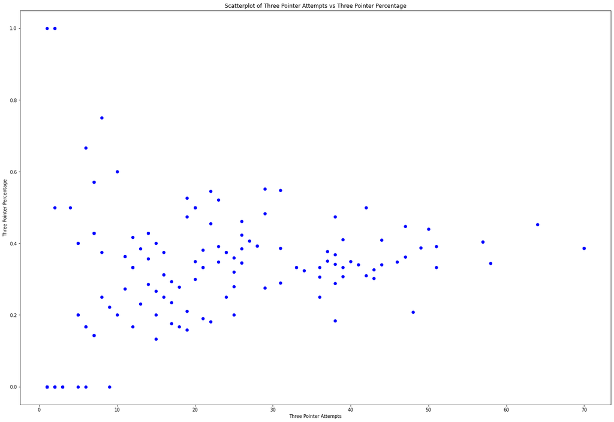

```python
# Set configurations for the scatterplot and then plot the graph
fig = plt.figure()
ax = fig.add_axes([0,0,3,3])
ax.scatter(finalPlayoffSeason["3PA"], finalPlayoffSeason["3Perc"] , color='b')
ax.set_xlabel('Three Pointer Attempts')
ax.set_ylabel('Three Pointer Percentage')
ax.set_title('Scatterplot of Three Pointer Attempts vs Three Pointer Percentage')
fig.show()
```

Here, we can see that there are two players with a 100% three point percentage and several players with a 0% three point percentage. This is likely because most of these players have very low three point attempts; thus, the percentages will be very extreme and volatile. For example, if a player takes only a single shot attempt and they make it, they will technically be a "100%" three point shooter. Likewise, if they miss their only shot attempt, they will statistically be a "0%" three point shooter. However, as a representation of a player's scoring ability, this is inaccurate. An analogy to statistics is that we need a decent sized sample size to make conclusions about our dataset. In this case, the sample size for these players refers to the three point attempts; thus, we cannot make an accurate judgement of a player's scoring abilities with such low sample size so we will remove these data points from our dataset. **We can see that the player with the largest number of three point attempts that still has a 0% or 100% shooting percentage has taken roughly 9 shots.** So, we will set that player's number of attempts to be the cutoff of the minimum number of attempts required to be an accurate representation of a player's scoring ability (not including that value). In order to get the precise value, we will analyze the table instead of eyeballing it.

```python
indexRemoved = []
max = 0

# Iterate through the dataset and then remove the "bad data"
for index, row in finalPlayoffSeason.iterrows():
    if row["3Perc"] == 0 or row["3Perc"] == 1:
        indexRemoved.append(index)

        if row["3PA"] > max:
            max = row["3PA"]

playOffSeasonCleaned = finalPlayoffSeason.drop(indexRemoved, axis = 0)
print(max)
```

```
9
```

We will repeat this same process for two point attempts.

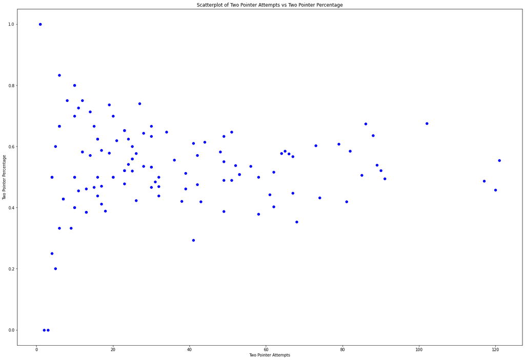

```python
# Set configurations for the scatterplot and then plot the graph
fig = plt.figure()
ax = fig.add_axes([0,0,3,3])
ax.scatter(playOffSeasonCleaned["2PA"], playOffSeasonCleaned["2Perc"] , color='b')
ax.set_xlabel('Two Pointer Attempts')
ax.set_ylabel('Two Pointer Percentage')
ax.set_title('Scatterplot of Two Pointer Attempts vs Two Pointer Percentage')
fig.show()
```

```python
indexRemoved = []
max = 0

# Remove bad data for two pointers
for index, row in playOffSeasonCleaned.iterrows():
    if row["2Perc"] == 0 or row["2Perc"] == 1:
        indexRemoved.append(index)
        if row["2PA"] > max:
            max = row["2PA"]

playOffSeasonCleanedTwos = playOffSeasonCleaned.drop(indexRemoved, axis = 0)
print(max)
```

```
3
```

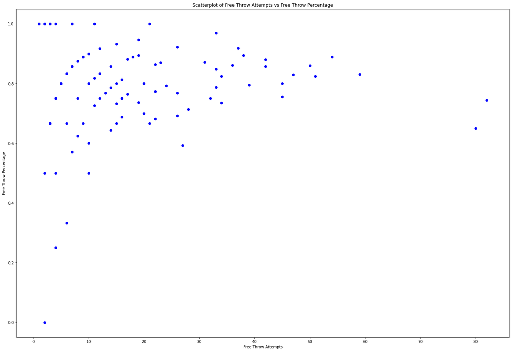

```python
# Set configurations for the scatterplot and then plot the graph
fig = plt.figure()
ax = fig.add_axes([0,0,3,3])
ax.scatter(playOffSeasonCleanedTwos["FTA"], playOffSeasonCleanedTwos["FT%"] , color='b')
ax.set_xlabel('Free Throw Attempts')
ax.set_ylabel('Free Throw Percentage')
ax.set_title('Scatterplot of Free Throw Attempts vs Free Throw Percentage')
fig.show()
```

Instead of repeating the same process as we did for two and three point shots, *we will not conduct any data cleaning for free throw attempts.* We can see that there is a player with roughly 20 shot attempts that still shot successfully 100% of the time. Thus, if we =move all entries with 20 or less shot attempts we will remove a significant number of samples.

Also, the same reasoning that we used to remove entries for two and three point attempts does not apply in the same way for free throw attempts. In basketball, especially in professional basketball, free throws are points that are "supposed to be made" and so it is reasonable to say that a player is a "100%" free throw shooter because many players in the NBA have free throw percentages above 90%. In contrast, the best shooters in the world, have roughly 40% three point percentages. For example, Steph Curry, one of the greatest shooters of all-time, has a three point percentage of 42.8% in his career at the time of writing.

In addition to plotting shooting percentages, **we will plot the distribution of points per game as the number of points per game a player has is ultimately the best indicator of how much they score.**

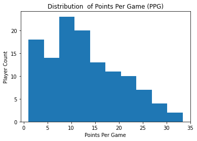

```python
# Plotting histogram
plt.hist(playOffSeasonCleanedTwos["PPG"])
plt.title("Distribution  of Points Per Game (PPG)")
plt.xlabel("Points Per Game")
plt.ylabel("Player Count")
plt.show()
```

Now, we will conduct the exact same set of steps for the EDA for the regular season dataset.

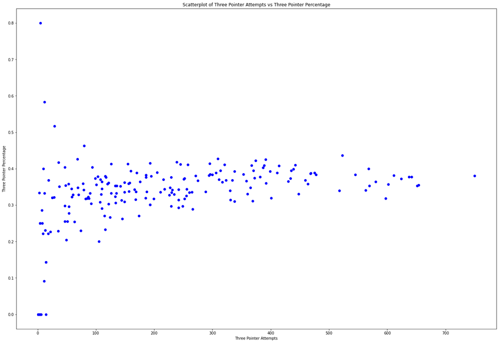

```python
# Set configurations for the scatterplot and then plot the graph
fig = plt.figure()
ax = fig.add_axes([0,0,3,3])
ax.scatter(finalRegularSeason["3PA"], finalRegularSeason["3Perc"] , color='b')
ax.set_xlabel('Three Pointer Attempts')
ax.set_ylabel('Three Pointer Percentage')
ax.set_title('Scatterplot of Three Pointer Attempts vs Three Pointer Percentage')
fig.show()
```

```python
indexRemoved = []
max = 0

# Iterate through the dataset and then remove the "bad data"
for index, row in finalRegularSeason.iterrows():
    if row["3Perc"] == 0 or row["3Perc"] == 1:
        indexRemoved.append(index)

        if row["3PA"] > max:
            max = row["3PA"]

regularSeasonCleaned = finalRegularSeason.drop(indexRemoved, axis = 0)
print(max)
```

```
14
```

Removing "bad data" for two pointers

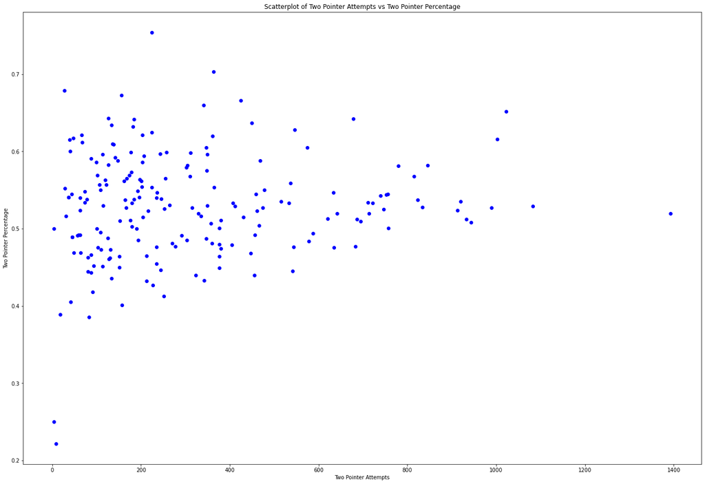

```python
# Set configurations for the scatterplot and then plot the graph
fig = plt.figure()
ax = fig.add_axes([0,0,3,3])
ax.scatter(regularSeasonCleaned["2PA"], regularSeasonCleaned["2Perc"] , color='b')
ax.set_xlabel('Two Pointer Attempts')
ax.set_ylabel('Two Pointer Percentage')
ax.set_title('Scatterplot of Two Pointer Attempts vs Two Pointer Percentage')
fig.show()
```

Here, we can actually see there are no players with 100% shooting percentage, so we do not need to remove any entries.

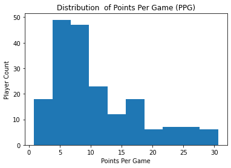

```python
# Plotting histogram
plt.hist(regularSeasonCleaned["PPG"])
plt.title("Distribution  of Points Per Game (PPG)")
plt.xlabel("Points Per Game")
plt.ylabel("Player Count")
plt.show()
```

Here, we can see that *most players score around 5-10 points per game.* We can see that the distributions for points per game for both seasons look very similar. We can also see that there are no egregious outliers and the distribution looks fairly normal.

### *Hypothesis Testing:*

At this point, we've collected our data, cleaned it, and have analyzed it. Now, it is ready for hypothesis testing. Hypothesis testing is a very general term that can refer to a multitude of methods; in this study, we are conducting a linear regression analysis. Here is a great guide on [how to perform a linear regression analysis](https://online.stat.psu.edu/stat501/lesson/6/6.4). Basically, we are trying to see whether our hypothesis is true or not.

Recall that we are trying to predict a player's assists per game based on some of their scoring statistics. *Our hypothesis is that as a player's scoring statistics increase, their assists per game will decrease because they are more of a scorer and not a facilitator.* Because points per game is arguably the "most important" statistic relating to a player's scoring abilities, we will begin by analyzing the linear relationship between points per game and assists per game. Note: We will first conduct the hypothesis testing on the playoffs dataset and then the regular season dataset.

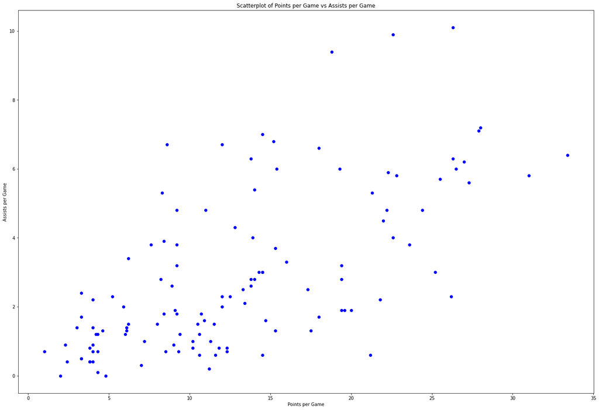

```python
# Set configurations for the scatterplot and then plot the graph
fig = plt.figure()
ax = fig.add_axes([0,0,3,3])
ax.scatter(playOffSeasonCleanedTwos["PPG"], playOffSeasonCleanedTwos["APG"] , color='b')
ax.set_xlabel('Points per Game')
ax.set_ylabel('Assists per Game')
ax.set_title('Scatterplot of Points per Game vs Assists per Game')
fig.show()
```

At this point it is clear (based on our intuition) that *our hypothesis is incorrect as there is not a negative linear relationship between points per game and assists per game.* In fact, there appears to be a *positive correlation between these two variables* as the points seem to be trending upwards across the x-axis. Before we make any conclusions, let's plot the relationship between assists per game and some of the other scoring statistics.

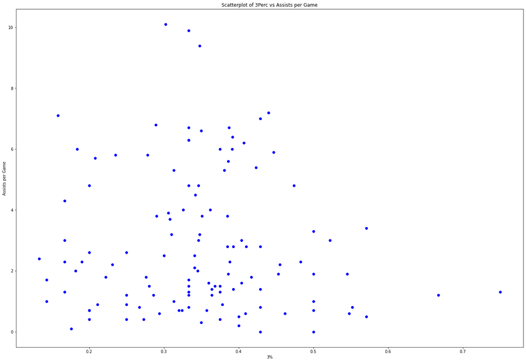

```python
# Set configurations for the scatterplot and then plot the graph
fig = plt.figure()
ax = fig.add_axes([0,0,3,3])
ax.scatter(playOffSeasonCleanedTwos["3Perc"], playOffSeasonCleanedTwos["APG"] , color='b')
ax.set_xlabel('3%')
ax.set_ylabel('Assists per Game')
ax.set_title('Scatterplot of 3Perc vs Assists per Game')
fig.show()
```

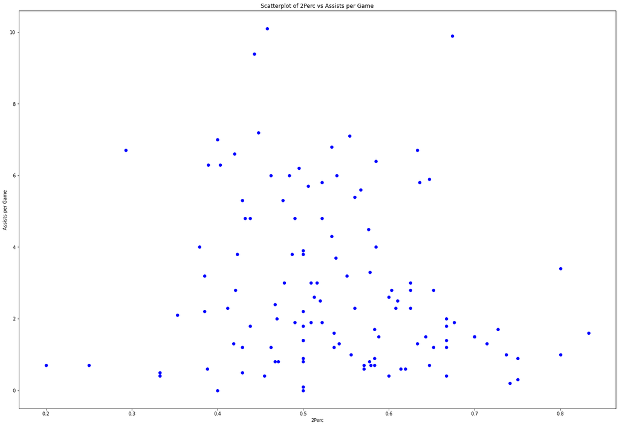

```python
# Set configurations for the scatterplot and then plot the graph
fig = plt.figure()
ax = fig.add_axes([0,0,3,3])
ax.scatter(playOffSeasonCleanedTwos["2Perc"], playOffSeasonCleanedTwos["APG"] , color='b')
ax.set_xlabel('2Perc')
ax.set_ylabel('Assists per Game')
ax.set_title('Scatterplot of 2Perc vs Assists per Game')
fig.show()
```

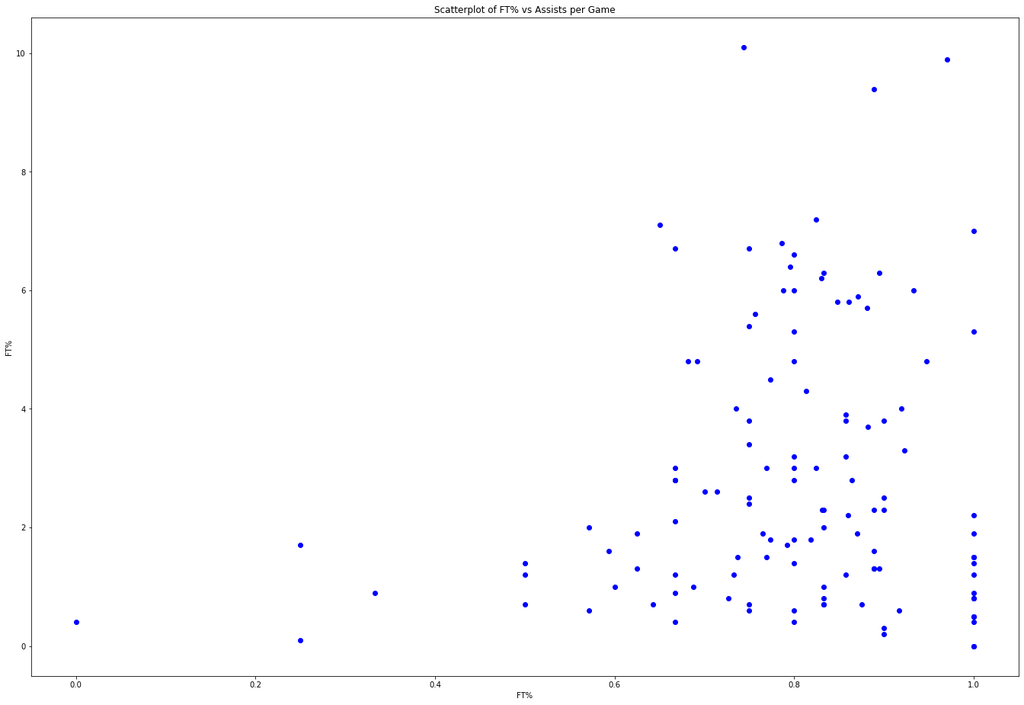

```python
# Set configurations for the scatterplot and then plot the graph
fig = plt.figure()
ax = fig.add_axes([0,0,3,3])
ax.scatter(playOffSeasonCleanedTwos["FT%"], playOffSeasonCleanedTwos["APG"] , color='b')
ax.set_xlabel('FT%')
ax.set_ylabel('FT%')
ax.set_title('Scatterplot of FT% vs Assists per Game')
fig.show()
```

There appears to be a *positive relationship between FT% and assists per game* as well. However, for *2 and 3 point percentages, the relationship is unclear.* So, we will use these scoring characteristics to see if we can predict a player's number of assists per game. We will continue to test our hypothesis in this way because this information will still be useful and testing these variables in our hypothesis still makes sense. Now, the hypothesis becomes clear in terms of which variables we want to test: *Is there a negative linear relationship between being a better shooter (in terms of 2 point and 3 point percentages) and being a more frequent passer (in terms of number of assists per game)?*

Before we conduct the regression, we should ask ourselves: *"Why is there a positive correlation between both PPG and APG & FT% & APG.*

As for the PPG and APG relationship, one very plausible explanation is the fact that each player has a **different amount of playing time.** *For example, superstar players may play for almost the entire 48 minute duration of an NBA game, while benchwarmers may only get a few minutes or even seconds.* Thus, superstars will have more opportunities to both increase their points and assists.

As for the relationship between FT% and APG, we may have a similar explanation saying that in general, **there are players who are better at both shooting and passing in general, while some players are worse at both. Thus, both variables will increase at at the same time.**

*In data science, one of the most important principles is to understand possible reasons of why our data behaves the way it does and adjust our studies accordingly.*

Proceeding with the analysis, we know that we want to include **both 2 and 3 point percentages as predictors for APG.** However, we need to determine whether we want to account for an interaction term. *When conducting a linear regression analysis, an interaction term is required if one independent variable has an effect on the way another independent variables affects the dependent variable.* For a more detailed explanation, check out [this pdf](https://www.medicine.mcgill.ca/epidemiology/joseph/courses/EPIB-621/interaction.pdf).

We will begin by plotting the linear regression line for 2 pointers and APG.

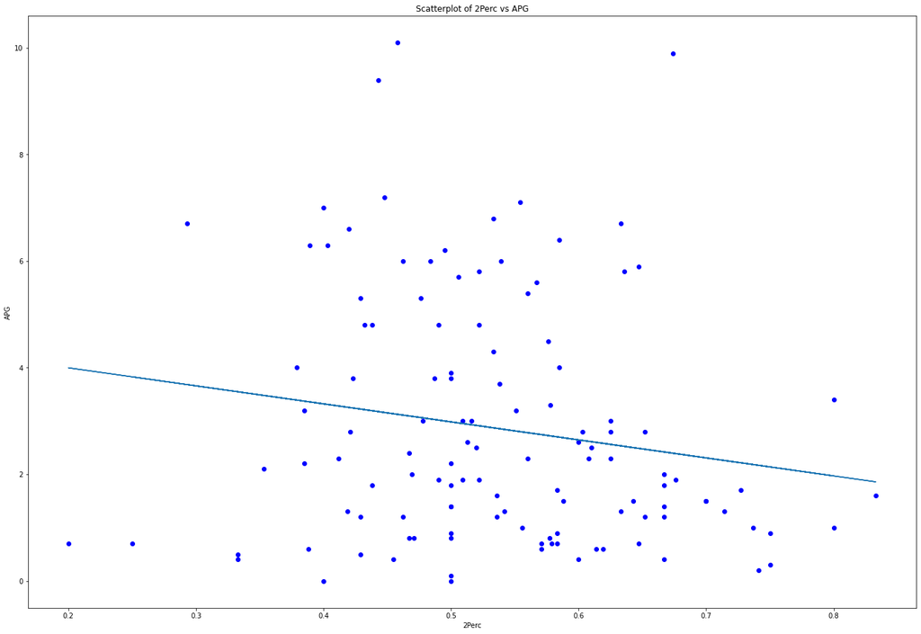

```python
# Set configurations for the scatterplot and then plot the graph
fig = plt.figure()
ax = fig.add_axes([0,0,3,3])
ax.scatter(playOffSeasonCleanedTwos["2Perc"], playOffSeasonCleanedTwos["APG"] , color='b')
ax.set_xlabel('2Perc')
ax.set_ylabel('APG')
ax.set_title('Scatterplot of 2Perc vs APG')


# Plotting regression line
reg_line = np.polyfit(playOffSeasonCleanedTwos["2Perc"], playOffSeasonCleanedTwos["APG"], 1)
reg_line_graph = np.poly1d(reg_line)
ax.plot(playOffSeasonCleanedTwos["2Perc"], reg_line_graph(playOffSeasonCleanedTwos["2Perc"]))
plt.show()
```

Great! Now we can view the regression line. To get specific insight into the regression line, we can retrieve the coefficients and intercepts.

```python
# Printing the equation for line of best fit
x = (playOffSeasonCleanedTwos["2Perc"]).values.reshape(-1,1)
y = playOffSeasonCleanedTwos["APG"]
reg = LinearRegression().fit(x, y)
print("y =", reg.coef_[0], "x +", reg.intercept_)
```

```
y = -3.379776799191027 x + 4.673430175926363
```

Now, we want to see if we need an interaction term. So, we will plot the residuals from the linear model we've created across 3P%.

```python
residualList = []

for index, row in playOffSeasonCleanedTwos.iterrows():
    # Calculate residuals (actual y - predicted y) for each x value and then store them so we can plot them
    actualY = row["APG"]
    predictedY = (reg.coef_[0] * row["2Perc"]) + reg.intercept_
    residual = actualY - predictedY
    residualList.append(residual)
```

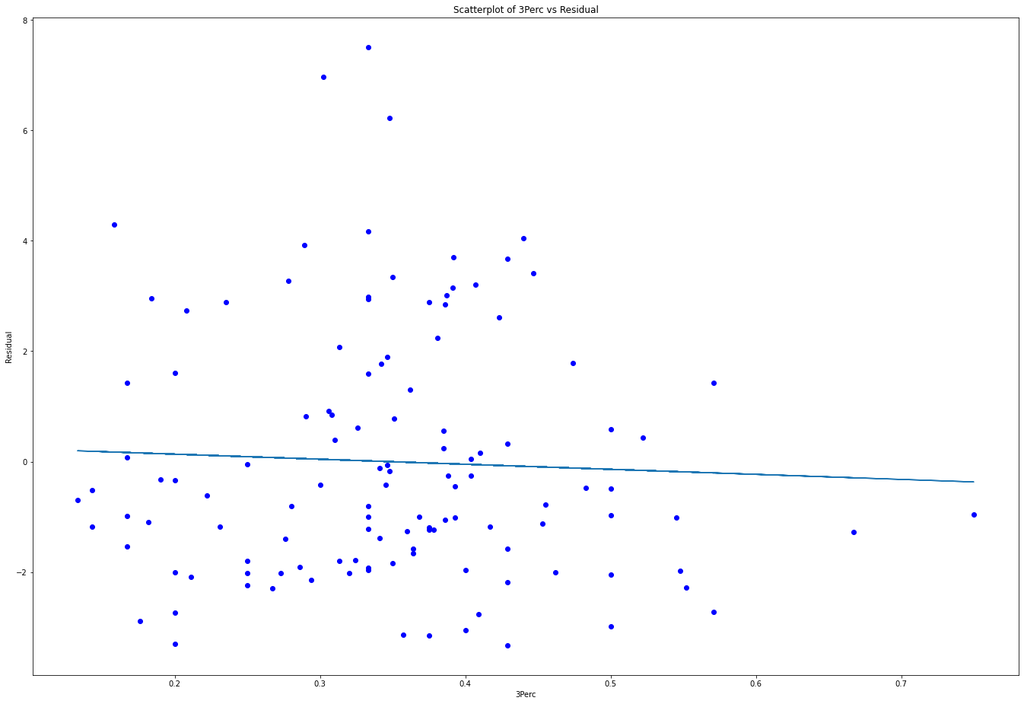

```python
# Set configurations for the scatterplot and then plot the graph
fig = plt.figure()
ax = fig.add_axes([0,0,3,3])
ax.scatter(playOffSeasonCleanedTwos["3Perc"], residualList , color='b')
ax.set_xlabel('3Perc')
ax.set_ylabel('Residual')
ax.set_title('Scatterplot of 3Perc vs Residual')

# Plotting regression line
reg_line = np.polyfit(playOffSeasonCleanedTwos["3Perc"], residualList, 1)
reg_line_graph = np.poly1d(reg_line)
ax.plot(playOffSeasonCleanedTwos["3Perc"], reg_line_graph(playOffSeasonCleanedTwos["3Perc"]))
plt.show()
```

```python
# Calculating correlation coefficient to see if there is a dependence between the model residual and 3P%
corr,_= pearsonr(playOffSeasonCleanedTwos["3Perc"], residualList )
```

Finally, let's calculate the linear regression line for both 3P% and 2P%

```python
# Calculating line of best fit again
X = playOffSeasonCleanedTwos[["2Perc", "3Perc"]]
y = playOffSeasonCleanedTwos["APG"]

reg = LinearRegression().fit(X, y)

print("y =", reg.coef_[0], "a + ", reg.coef_[1], "b +", reg.intercept_)
```

```
y = -3.2268412993975866 a +  -0.940799441962319 b + 4.91872583616391
```

```python
# Rename columns so we can set formula correctly
playOffSeasonCleanedTwos.rename(columns = {"2Perc": "TwoPerc", "3Perc": "ThreePerc"}, inplace = True)
# RENAME THE COLUMNS FOR THE REGULAR SEASON DATASE TOO

# Conducting multiple linear regression analysis
# The formula basically says APG is the dependent variable and TwoPerc and ThreePerc are the independent variables
formula = 'APG ~ TwoPerc + ThreePerc'
lm = ols(formula, playOffSeasonCleanedTwos).fit()

print(lm.rsquared)
print(lm.rsquared_adj)
```

```
0.03049756624288469
0.01420340769234496
```

Here, we can see that the rsquared and r-squared adjusted values are both very low, meaning that there is **very weak correlation between the two independent variables, two point and three point shooting percentages, and APG.** If you want to view more information about the analysis, you can use the summary() function to get a variety of statistics!

```python
lm.summary()
```

OLS Regression Results

| Dep. Variable: | APG | R-squared: | 0.030 |
| --- | --- | --- | --- |
| Model: | OLS | Adj. R-squared: | 0.014 |
| Method: | Least Squares | F-statistic: | 1.872 |
| Date: | Mon, 16 May 2022 | Prob (F-statistic): | 0.158 |
| Time: | 04:20:39 | Log-Likelihood: | -272.14 |
| No. Observations: | 122 | AIC: | 550.3 |
| Df Residuals: | 119 | BIC: | 558.7 |
| Df Model: | 2 |  |  |
| Covariance Type: | nonrobust |  |  |

|  | coef | std err | t | P>\|t\| | [0.025 | 0.975] |
| --- | --- | --- | --- | --- | --- | --- |
| Intercept | 4.9187 | 1.108 | 4.440 | 0.000 | 2.725 | 7.112 |
| TwoPerc | -3.2268 | 1.834 | -1.760 | 0.081 | -6.858 | 0.404 |
| ThreePerc | -0.9408 | 1.890 | -0.498 | 0.620 | -4.683 | 2.802 |

| Omnibus: | 17.160 | Durbin-Watson: | 2.188 |
| --- | --- | --- | --- |
| Prob(Omnibus): | 0.000 | Jarque-Bera (JB): | 19.697 |
| Skew: | 0.951 | Prob(JB): | 5.28e-05 |
| Kurtosis: | 3.509 | Cond. No. | 11.9 |

Notes:  
[1] Standard Errors assume that the covariance matrix of the errors is correctly specified.

Repeating process for regular season dataset.

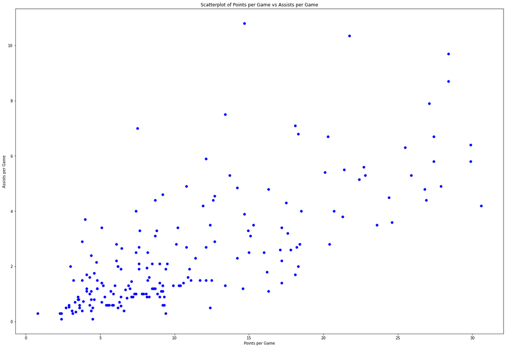

```python
# Set configurations for the scatterplot and then plot the graph
fig = plt.figure()
ax = fig.add_axes([0,0,3,3])
ax.scatter(regularSeasonCleaned["PPG"], regularSeasonCleaned["APG"] , color='b')
ax.set_xlabel('Points per Game')
ax.set_ylabel('Assists per Game')
ax.set_title('Scatterplot of Points per Game vs Assists per Game')
fig.show()
```

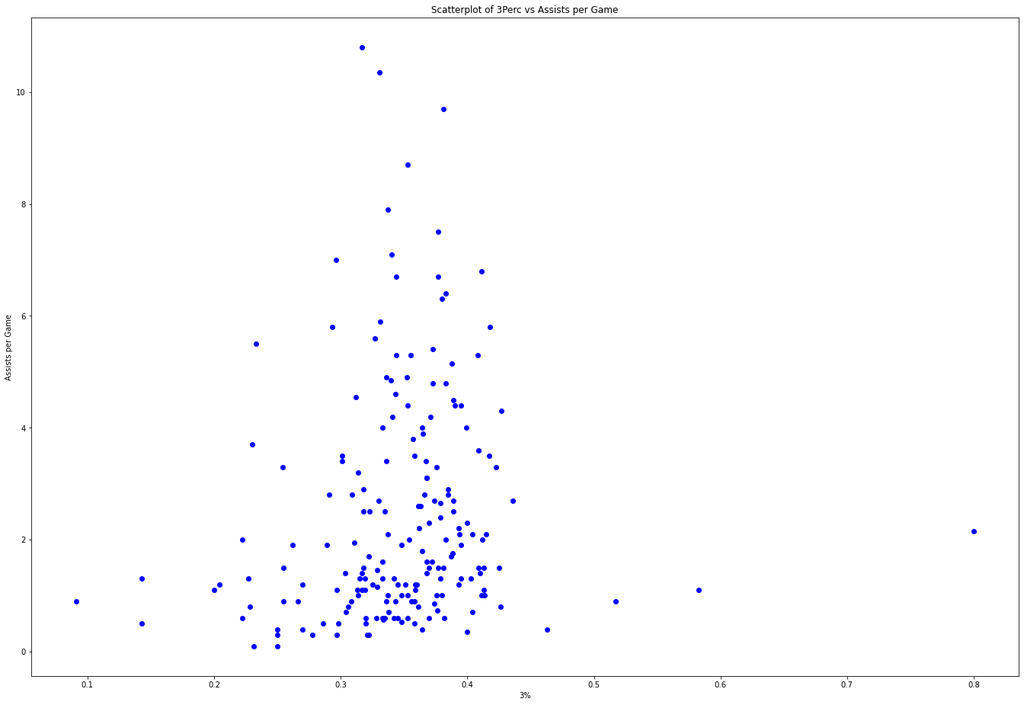

```python
# Set configurations for the scatterplot and then plot the graph
fig = plt.figure()
ax = fig.add_axes([0,0,3,3])
ax.scatter(regularSeasonCleaned["3Perc"], regularSeasonCleaned["APG"] , color='b')
ax.set_xlabel('3%')
ax.set_ylabel('Assists per Game')
ax.set_title('Scatterplot of 3Perc vs Assists per Game')
fig.show()
```

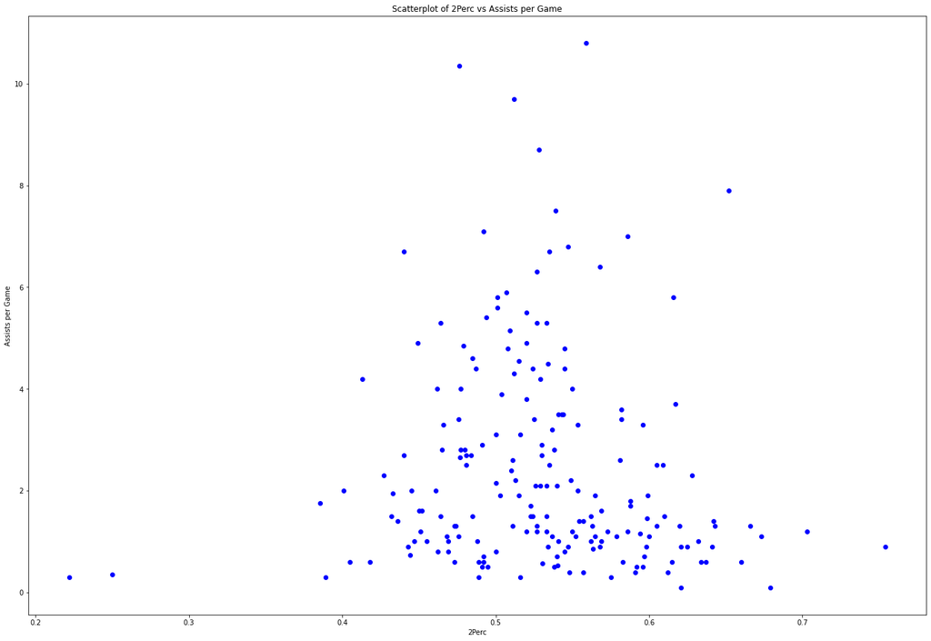

```python
# Set configurations for the scatterplot and then plot the graph
fig = plt.figure()
ax = fig.add_axes([0,0,3,3])
ax.scatter(regularSeasonCleaned["2Perc"], regularSeasonCleaned["APG"] , color='b')
ax.set_xlabel('2Perc')
ax.set_ylabel('Assists per Game')
ax.set_title('Scatterplot of 2Perc vs Assists per Game')
fig.show()
```

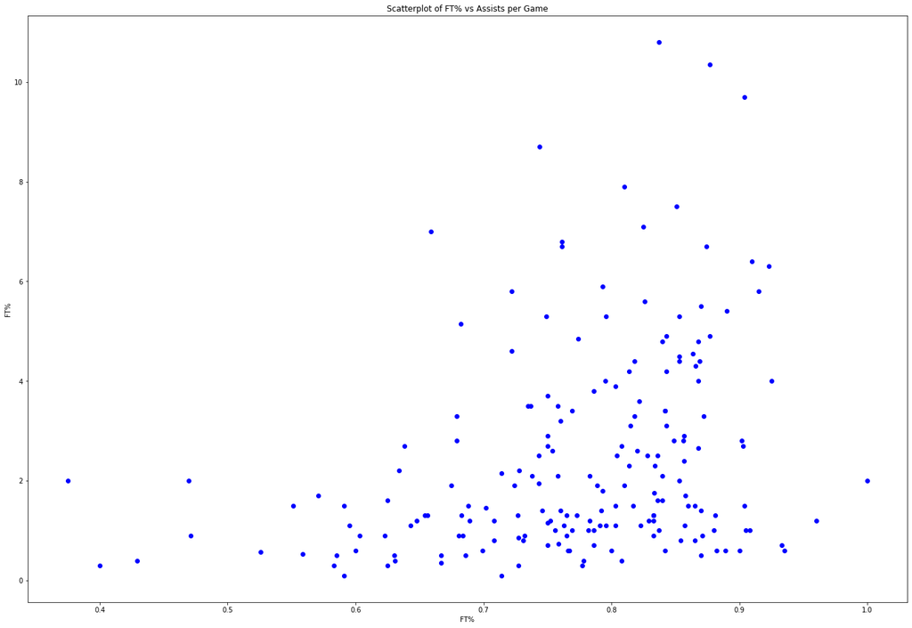

```python
# Set configurations for the scatterplot and then plot the graph
fig = plt.figure()
ax = fig.add_axes([0,0,3,3])
ax.scatter(regularSeasonCleaned["FT%"], regularSeasonCleaned["APG"] , color='b')
ax.set_xlabel('FT%')
ax.set_ylabel('FT%')
ax.set_title('Scatterplot of FT% vs Assists per Game')
fig.show()
```

Similar to the playoffs dataset, there is a clear positive linear relationship for the APG across FT% graph and the APG across PPG graph. Thus, using the reasoning stated prior, we will conduct our analysis using the 2P% and 3P% independent variables. First, as before, we will determine if we need an interaction term.

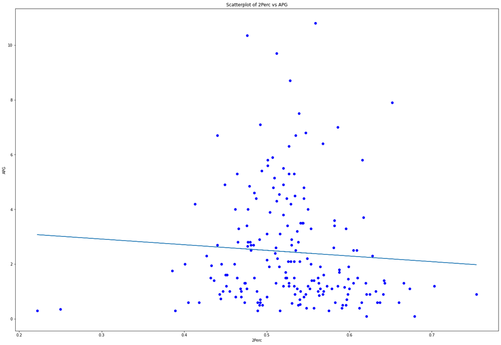

```python
# Set configurations for the scatterplot and then plot the graph
fig = plt.figure()
ax = fig.add_axes([0,0,3,3])
ax.scatter(regularSeasonCleaned["2Perc"], regularSeasonCleaned["APG"] , color='b')
ax.set_xlabel('2Perc')
ax.set_ylabel('APG')
ax.set_title('Scatterplot of 2Perc vs APG')


# Plotting regression line
reg_line = np.polyfit(regularSeasonCleaned["2Perc"], regularSeasonCleaned["APG"], 1)
reg_line_graph = np.poly1d(reg_line)
ax.plot(regularSeasonCleaned["2Perc"], reg_line_graph(regularSeasonCleaned["2Perc"]))
plt.show()
```

```python
# Printing the equation for line of best fit
x = (regularSeasonCleaned["2Perc"]).values.reshape(-1,1)
y = regularSeasonCleaned["APG"]
reg = LinearRegression().fit(x, y)
print("y =", reg.coef_[0], "x +", reg.intercept_)
```

```
y = -2.0625786209888166 x + 3.5328253905243034
```

```python
residualList = []

for index, row in regularSeasonCleaned.iterrows():
    # Calculate residuals (actual y - predicted y) for each x value and then store them so we can plot them
    actualY = row["APG"]
    predictedY = (reg.coef_[0] * row["2Perc"]) + reg.intercept_
    residual = actualY - predictedY
    residualList.append(residual)
```

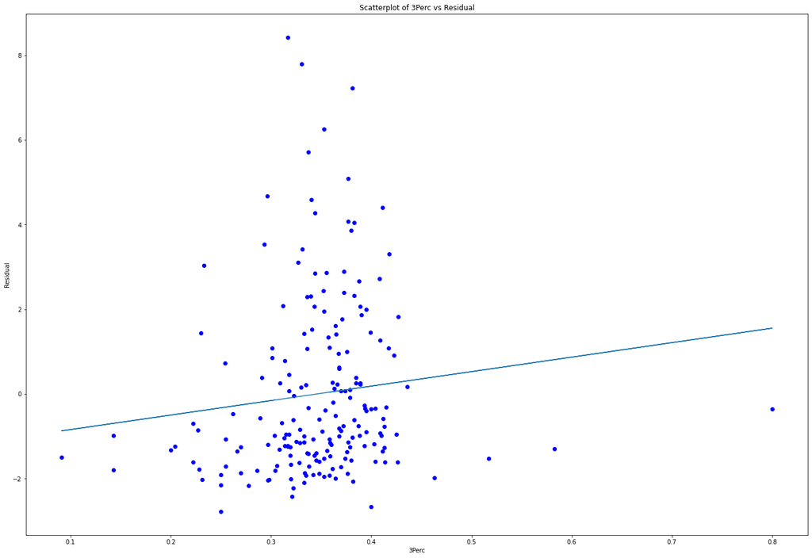

```python
# Set configurations for the scatterplot and then plot the graph
fig = plt.figure()
ax = fig.add_axes([0,0,3,3])
ax.scatter(regularSeasonCleaned["3Perc"], residualList , color='b')
ax.set_xlabel('3Perc')
ax.set_ylabel('Residual')
ax.set_title('Scatterplot of 3Perc vs Residual')

# Plotting regression line
reg_line = np.polyfit(regularSeasonCleaned["3Perc"], residualList, 1)
reg_line_graph = np.poly1d(reg_line)
ax.plot(regularSeasonCleaned["3Perc"], reg_line_graph(regularSeasonCleaned["3Perc"]))
plt.show()
```

```python
# Calculating correlation coefficient to see if there is a dependence between the model residual and 3P%
corr,_= pearsonr(regularSeasonCleaned["3Perc"], residualList )
corr
```

```
0.11306746866978322
```

Here, we can see there is **no need for an interaction term because the correlation between 3P% and the model residual is weak!** Now, we will conduct the multiple linear regression analysis with APG across 2P% and 3P%

```python
# Calculating line of best fit again
X = regularSeasonCleaned[["2Perc", "3Perc"]]
y = regularSeasonCleaned["APG"]

reg = LinearRegression().fit(X, y)

print("y =", reg.coef_[0], "a + ", reg.coef_[1], "b +", reg.intercept_)
```

```
y = -1.691931819454497 a +  3.4642528764006846 b + 2.135649532820194
```

```python
# Rename columns so we can set formula correctly
regularSeasonCleaned.rename(columns = {"2Perc": "TwoPerc", "3Perc": "ThreePerc"}, inplace = True)
# RENAME THE COLUMNS FOR THE REGULAR SEASON DATASE TOO

# Conducting multiple linear regression analysis
# The formula basically says APG is the dependent variable and TwoPerc and ThreePerc are the independent variables
formula = 'APG ~ TwoPerc + ThreePerc'
lm = ols(formula, regularSeasonCleaned).fit()

print(lm.rsquared)
print(lm.rsquared_adj)
```

```
0.017672342431362398
0.007332051299060893
```

Here, we can see that the r squared value and r squared adjusted value are very low. Thus, there is a **very weak correlation between the independent variables and the dependent variables.**

### *Communication of Insights Attained:*

The last step in the data science pipeline is communicating the results of our analysis. The research that we've done is pointless if the audience cannot understand! Thus, it is important to explain the results in terms of its applications and not solely the technical details. In addition, it is great to provide the audience with a possible explanation of why the results came out the way they did.

After conducting a linear regression analysis on whether a player's two-point and three-point shooting percentages are correlated to assists per game, we have concluded that there is no correlation for both the regular season and playoffs. Although this did not match our original hypothesis, once again, it's important to try and reason why this occurred. As mentioned prior, **this may be because better players (who therefore have higher shooting percentages) receive more playing time in general; thus, they will have more assists per game as well as greater shooting percentages.**

*Although this analysis did not prove to be useful in the sense that we did not find a negative correlation between our studied variables, it has shown us that there may be a positive correlation between points per game and free throw percentage with assists per game. Thus, if we would like to continue analyzing how a player's general scoring abilities impact assists per game, we could take these variables and conduct a very similar analysis to what we've done here.*

[figure not shown]

[James Harden]